# Project: Visualizing FordGoBike Data By Karim Goudy

> The dataset consists of 183412 bike riding records over 16 different informations of a bike sharing serive by Ford. Let's dive into it !
- Preliminary Wrangling
  - Data Gathering & Assessing
  - Data Cleaning
- Data Exploration
  - Univariate Exploration
  - Bivariate Exploration
  - Multivariate Exploration

## Introduction

> The Bay Area's bike share scheme is Ford GoBike. Bay Area Bike Share was launched in 2013 as a regional test program, with 700 bikes and 70 stations spread between San Francisco and San Jose. Ford GoBike will have 7,000 bikes throughout San Francisco, the East Bay, and San Jose after the expansion is complete.

> Ford GoBike, like other bike sharing systems, is made up of a fleet of specifically built, strong, and durable bikes that are docked at a network of docking stations located around the city. The bikes may be unlocked at any station in the system and returned to any other station, making them perfect for one-way excursions. People use bike sharing to travel to work or school, to conduct errands, to get to appointments or social events, and for other purposes. It's a fun, easy, and inexpensive way to go about.

> The bikes are accessible for use 24 hours a day, seven days a week, 365 days a year, and riders who become members or purchase passes have access to all bikes in the network. The data may be found here. https://www.fordgobike.com/system-data

## Dataset Overview¶

The dataset used in this research comes from the Ford GoBike sharing system in the wider San Francisco Bay region in 2019. (February). Wikipedia has a page dedicated to Bay Wheels. It is made up of different riding features as well as rider attributes.

The following characteristics from the cleaned dataset were investigated:

- Duration of the journey (seconds)
- Start Day
- Start Time
- Type of User ("Subscriber" = Member or "Customer" = Casual)
- Age of the Member
- Gender of the Member

## Preliminary Data Wrangling

In this section we will import our lib and create a data frame for our Data

```python
import pandas as pd
import numpy as np
import matplotlib.pyplot as plt
import seaborn as sb
import requests
import datetime

sb.set_style('darkgrid')
%matplotlib inline
```

```python
pwd
```

```
'C:\\Users\\karee'
```

```python
# Read the data from a CSV file
df = pd.read_csv(r'C:\Users\karee\Downloads\201902-fordgobike-tripdata (1).csv')
```

```python
# Showing the first five rows of the newly combined dataset
df.head()
```

|  | duration_sec | start_time | end_time | start_station_id | start_station_name | start_station_latitude | start_station_longitude | end_station_id | end_station_name | end_station_latitude | end_station_longitude | bike_id | user_type | member_birth_year | member_gender | bike_share_for_all_trip |
| --- | --- | --- | --- | --- | --- | --- | --- | --- | --- | --- | --- | --- | --- | --- | --- | --- |
| 0 | 52185 | 2019-02-28 17:32:10.1450 | 2019-03-01 08:01:55.9750 | 21.0 | Montgomery St BART Station (Market St at 2nd St) | 37.789625 | -122.400811 | 13.0 | Commercial St at Montgomery St | 37.794231 | -122.402923 | 4902 | Customer | 1984.0 | Male | No |
| 1 | 42521 | 2019-02-28 18:53:21.7890 | 2019-03-01 06:42:03.0560 | 23.0 | The Embarcadero at Steuart St | 37.791464 | -122.391034 | 81.0 | Berry St at 4th St | 37.775880 | -122.393170 | 2535 | Customer | NaN | NaN | No |
| 2 | 61854 | 2019-02-28 12:13:13.2180 | 2019-03-01 05:24:08.1460 | 86.0 | Market St at Dolores St | 37.769305 | -122.426826 | 3.0 | Powell St BART Station (Market St at 4th St) | 37.786375 | -122.404904 | 5905 | Customer | 1972.0 | Male | No |
| 3 | 36490 | 2019-02-28 17:54:26.0100 | 2019-03-01 04:02:36.8420 | 375.0 | Grove St at Masonic Ave | 37.774836 | -122.446546 | 70.0 | Central Ave at Fell St | 37.773311 | -122.444293 | 6638 | Subscriber | 1989.0 | Other | No |
| 4 | 1585 | 2019-02-28 23:54:18.5490 | 2019-03-01 00:20:44.0740 | 7.0 | Frank H Ogawa Plaza | 37.804562 | -122.271738 | 222.0 | 10th Ave at E 15th St | 37.792714 | -122.248780 | 4898 | Subscriber | 1974.0 | Male | Yes |

```python
df.shape
```

```
(183412, 16)
```

```python
# Let's take a peak into the data's basic information
df.info(show_counts = True)
```

```
<class 'pandas.core.frame.DataFrame'>
RangeIndex: 183412 entries, 0 to 183411
Data columns (total 16 columns):
 #   Column                   Non-Null Count   Dtype
---  ------                   --------------   -----
 0   duration_sec             183412 non-null  int64
 1   start_time               183412 non-null  object
 2   end_time                 183412 non-null  object
 3   start_station_id         183215 non-null  float64
 4   start_station_name       183215 non-null  object
 5   start_station_latitude   183412 non-null  float64
 6   start_station_longitude  183412 non-null  float64
 7   end_station_id           183215 non-null  float64
 8   end_station_name         183215 non-null  object
 9   end_station_latitude     183412 non-null  float64
 10  end_station_longitude    183412 non-null  float64
 11  bike_id                  183412 non-null  int64
 12  user_type                183412 non-null  object
 13  member_birth_year        175147 non-null  float64
 14  member_gender            175147 non-null  object
 15  bike_share_for_all_trip  183412 non-null  object
dtypes: float64(7), int64(2), object(7)
memory usage: 22.4+ MB
```

```python
# Any duplicates?
df.duplicated().sum()
# No duplicates here - that was straightforward
```

```
0
```

```python
# What about NaN values?
df.isna().sum()
# It looks like some of the starting and ending values are NaN, along with member birth years and genders
```

```
duration_sec                  0
start_time                    0
end_time                      0
start_station_id            197
start_station_name          197
start_station_latitude        0
start_station_longitude       0
end_station_id              197
end_station_name            197
end_station_latitude          0
end_station_longitude         0
bike_id                       0
user_type                     0
member_birth_year          8265
member_gender              8265
bike_share_for_all_trip       0
dtype: int64
```

```python
# display the value counts of gender
df.member_gender.value_counts()
```

```
Male      130651
Female     40844
Other       3652
Name: member_gender, dtype: int64
```

```python
# create a column for the age of user
df['User_age']= 2020 - df.member_birth_year
```

```python
# descriptive statistics for User age
df.User_age.describe()
```

```
count    175147.000000
mean         35.193563
std          10.116689
min          19.000000
25%          28.000000
50%          33.000000
75%          40.000000
max         142.000000
Name: User_age, dtype: float64
```

```python
# remove any user age over 80 years
df= df[df['User_age'] <= 80]
```

```python
# Sampling the data helps the analyst understand the required cleaning needed, and get a feel for the data
df.sample(10)
```

|  | duration_sec | start_time | end_time | start_station_id | start_station_name | start_station_latitude | start_station_longitude | end_station_id | end_station_name | end_station_latitude | end_station_longitude | bike_id | user_type | member_birth_year | member_gender | bike_share_for_all_trip | User_age |
| --- | --- | --- | --- | --- | --- | --- | --- | --- | --- | --- | --- | --- | --- | --- | --- | --- | --- |
| 20527 | 331 | 2019-02-26 12:13:49.8020 | 2019-02-26 12:19:21.1800 | 305.0 | Ryland Park | 37.342725 | -121.895617 | 280.0 | San Fernando St at 7th St | 37.337122 | -121.883215 | 3890 | Subscriber | 1995.0 | Male | Yes | 25.0 |
| 154874 | 934 | 2019-02-06 09:09:34.1340 | 2019-02-06 09:25:08.3240 | 104.0 | 4th St at 16th St | 37.767045 | -122.390833 | 10.0 | Washington St at Kearny St | 37.795393 | -122.404770 | 5030 | Subscriber | 1993.0 | Female | No | 27.0 |
| 79656 | 3596 | 2019-02-18 16:19:55.9320 | 2019-02-18 17:19:52.7470 | 86.0 | Market St at Dolores St | 37.769305 | -122.426826 | 108.0 | 16th St Mission BART | 37.764710 | -122.419957 | 5912 | Subscriber | 1997.0 | Other | Yes | 23.0 |
| 164 | 2302 | 2019-02-28 22:07:11.3350 | 2019-02-28 22:45:33.7220 | 23.0 | The Embarcadero at Steuart St | 37.791464 | -122.391034 | 85.0 | Church St at Duboce Ave | 37.770083 | -122.429156 | 2651 | Subscriber | 1975.0 | Male | No | 45.0 |
| 87723 | 473 | 2019-02-16 23:12:25.9070 | 2019-02-16 23:20:19.2970 | 324.0 | Union Square (Powell St at Post St) | 37.788300 | -122.408531 | 58.0 | Market St at 10th St | 37.776619 | -122.417385 | 4750 | Customer | 1999.0 | Male | No | 21.0 |
| 31466 | 549 | 2019-02-24 16:42:20.9860 | 2019-02-24 16:51:30.7570 | 74.0 | Laguna St at Hayes St | 37.776435 | -122.426244 | 368.0 | Myrtle St at Polk St | 37.785434 | -122.419622 | 6323 | Customer | 1996.0 | Male | No | 24.0 |
| 94447 | 664 | 2019-02-15 16:22:17.1450 | 2019-02-15 16:33:21.9320 | 77.0 | 11th St at Natoma St | 37.773507 | -122.416040 | 77.0 | 11th St at Natoma St | 37.773507 | -122.416040 | 5404 | Subscriber | 1952.0 | Female | No | 68.0 |
| 162238 | 812 | 2019-02-05 12:10:43.4270 | 2019-02-05 12:24:15.5550 | 363.0 | Salesforce Transit Center (Natoma St at 2nd St) | 37.787492 | -122.398285 | 66.0 | 3rd St at Townsend St | 37.778742 | -122.392741 | 5021 | Subscriber | 1989.0 | Male | No | 31.0 |
| 64249 | 410 | 2019-02-20 12:35:48.6520 | 2019-02-20 12:42:39.3530 | 58.0 | Market St at 10th St | 37.776619 | -122.417385 | 356.0 | Valencia St at Clinton Park | 37.769188 | -122.422285 | 5858 | Subscriber | 1968.0 | Female | No | 52.0 |
| 87177 | 1132 | 2019-02-17 10:16:30.6870 | 2019-02-17 10:35:23.4520 | 197.0 | El Embarcadero at Grand Ave | 37.808848 | -122.249680 | 178.0 | Broadway at 30th St | 37.819381 | -122.261928 | 3516 | Subscriber | 1993.0 | Female | No | 27.0 |

```python
# Let's also get some additional description for stats figures
df.describe()
```

|  | duration_sec | start_station_id | start_station_latitude | start_station_longitude | end_station_id | end_station_latitude | end_station_longitude | bike_id | member_birth_year | User_age |
| --- | --- | --- | --- | --- | --- | --- | --- | --- | --- | --- |
| count | 174944.000000 | 174749.000000 | 174944.000000 | 174944.000000 | 174749.000000 | 174944.000000 | 174944.000000 | 174944.000000 | 174944.000000 | 174944.000000 |
| mean | 704.509574 | 139.024092 | 37.770794 | -122.351263 | 136.643683 | 37.770989 | -122.350839 | 4481.980182 | 1984.880888 | 35.119112 |
| std | 1642.477572 | 111.651112 | 0.101124 | 0.118499 | 111.352470 | 0.101031 | 0.118064 | 1658.354801 | 9.869501 | 9.869501 |
| min | 61.000000 | 3.000000 | 37.317298 | -122.453704 | 3.000000 | 37.317298 | -122.453704 | 11.000000 | 1941.000000 | 19.000000 |
| 25% | 323.000000 | 47.000000 | 37.770407 | -122.411901 | 44.000000 | 37.770407 | -122.411647 | 3802.000000 | 1980.000000 | 28.000000 |
| 50% | 511.000000 | 104.000000 | 37.780760 | -122.398279 | 101.000000 | 37.781010 | -122.397405 | 4959.000000 | 1987.000000 | 33.000000 |
| 75% | 789.000000 | 239.000000 | 37.797320 | -122.282497 | 238.000000 | 37.797673 | -122.285171 | 5505.000000 | 1992.000000 | 40.000000 |
| max | 84548.000000 | 398.000000 | 37.880222 | -121.874119 | 398.000000 | 37.880222 | -121.874119 | 6645.000000 | 2001.000000 | 79.000000 |

### Observations:

### What is the structure of your dataset?

All of these will need considerable study via exploratory visualizations!

**The main features of interest are :**

- Time and duration of rides
- Start and end station information
- Bike information
- User information

**What aspects of the dataset will aid your study into our points of interest?**

It will be interesting to observe how these bikes are used based on some of the category variables we will be developing. For example, we may look at the distinction between subscribing and not subscribing. Looking into the distributions of numerical variables might throw some light on some intriguing findings.

## Univariate Exploration

In this part, I'll concentrate on three number variables:

- Ride duration
- Age
- Travel Distance

For each one, I'll hunt for outliers using box plots, which will aid in cleaning and defining the bounds for a histogram plot to assess distribution. After that, I'll make a decision on each of them.

## Data Cleaning

We have a lot of data; are all of them useful? From a short glance, I discovered that we have some redundant data, such as (Station Id and Station Name), which we only need one of. I also don't see the necessity for the x, y coordinates of the stations, but I can create a lovely map of our travels, so let's keep it for now.

```python
# Before cleaning, make copy of original datasets
df_clean = df.copy()
```

Let's see if there is any duplicates

**Issue 1: Remove all null values (start station id, end station id, member birth year, and member gender).**

```python
df_clean.dropna(how = 'any', axis = 0, inplace=True)
# cant assume Station Ids or genders  so lets drop them
```

```python
# check whether null values are dropped
df_clean.isna().sum()
```

```
duration_sec               0
start_time                 0
end_time                   0
start_station_id           0
start_station_name         0
start_station_latitude     0
start_station_longitude    0
end_station_id             0
end_station_name           0
end_station_latitude       0
end_station_longitude      0
bike_id                    0
user_type                  0
member_birth_year          0
member_gender              0
bike_share_for_all_trip    0
User_age                   0
dtype: int64
```

**Issue 2: Erreneous data types**

- object to datetime conversion of start_time and end_time types
- member_birth_year's type should be changed from float to int.
- start_station_id, end_station id, and bike_id should all be converted to str type.
- Convert user_type and member_gender to category type.

```python
# convert the data type of start_time and end_time to datetime.
df_clean.start_time = pd.to_datetime(df_clean.start_time)
df_clean.end_time = pd.to_datetime(df_clean.end_time)

# convert member_birth_year from float64 to int
df_clean.member_birth_year = df_clean.member_birth_year.astype(int)

# convert ids from object to str
df_clean.start_station_id = df_clean.start_station_id.astype(str)
df_clean.end_station_id = df_clean.end_station_id.astype(str)
df_clean.bike_id = df_clean.bike_id.astype(str)


# convert user_type and member_gender datatype into category
df_clean.user_type = df_clean.user_type.astype('category')
df_clean.member_gender = df_clean.member_gender.astype('category')
```

```python
# check whether data type are converted correctly
df_clean.info()
```

```
<class 'pandas.core.frame.DataFrame'>
Int64Index: 174749 entries, 0 to 183411
Data columns (total 17 columns):
 #   Column                   Non-Null Count   Dtype
---  ------                   --------------   -----
 0   duration_sec             174749 non-null  int64
 1   start_time               174749 non-null  datetime64[ns]
 2   end_time                 174749 non-null  datetime64[ns]
 3   start_station_id         174749 non-null  object
 4   start_station_name       174749 non-null  object
 5   start_station_latitude   174749 non-null  float64
 6   start_station_longitude  174749 non-null  float64
 7   end_station_id           174749 non-null  object
 8   end_station_name         174749 non-null  object
 9   end_station_latitude     174749 non-null  float64
 10  end_station_longitude    174749 non-null  float64
 11  bike_id                  174749 non-null  object
 12  user_type                174749 non-null  category
 13  member_birth_year        174749 non-null  int32
 14  member_gender            174749 non-null  category
 15  bike_share_for_all_trip  174749 non-null  object
 16  User_age                 174749 non-null  float64
dtypes: category(2), datetime64[ns](2), float64(5), int32(1), int64(1), object(6)
memory usage: 21.0+ MB
```

## Question 1:

> **Is it possible to see the distribution of numerical variables? Let us begin with one of them: distance**

```python
# Calculate distance traveled by trip based on location of start and end station
# source : https://www.movable-type.co.uk/scripts/latlong.html

from math import cos, sin, sqrt, atan2, radians

# Create a function that calculates distance
def distance(df):
    R = 6373 # in km
    lat1 = radians(df['start_station_latitude'])
    lat2 = radians(df['end_station_latitude'])
    long1 = radians(df['start_station_longitude'])
    long2 = radians(df['end_station_longitude'])
    deltalong = long2 - long1
    deltalat = lat2 - lat1
    a = (sin(deltalat/2))**2 + cos(lat1) * cos(lat2) * (sin(deltalong/2))**2
    c = 2 * atan2(sqrt(a), sqrt(1-a))
    d = R * c
    return d #in km

#Calculate distance
df['distance'] = df.apply(distance,axis=1)
```

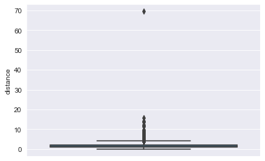

```python
# Check the maximum distance value and check if the function works.
sb.boxplot(data=df, y='distance');
```

> **70 kilometers for a bike ride is excessive and suspicious for this type of usage (city focused).**

```python
# Let's have a look at values over 15 km
df[df['distance'] > 15].head(10)
```

|  | duration_sec | start_time | end_time | start_station_id | start_station_name | start_station_latitude | start_station_longitude | end_station_id | end_station_name | end_station_latitude | end_station_longitude | bike_id | user_type | member_birth_year | member_gender | bike_share_for_all_trip | User_age | distance |
| --- | --- | --- | --- | --- | --- | --- | --- | --- | --- | --- | --- | --- | --- | --- | --- | --- | --- | --- |
| 19827 | 2229 | 2019-02-26 15:11:44.5230 | 2019-02-26 15:48:54.3730 | 227.0 | Foothill Blvd at Fruitvale Ave | 37.783757 | -122.222603 | 21.0 | Montgomery St BART Station (Market St at 2nd St) | 37.789625 | -122.400811 | 2080 | Subscriber | 1989.0 | Male | Yes | 31.0 | 15.678876 |
| 112038 | 6945 | 2019-02-12 14:28:44.4020 | 2019-02-12 16:24:30.1580 | 21.0 | Montgomery St BART Station (Market St at 2nd St) | 37.789625 | -122.400811 | 300.0 | Palm St at Willow St | 37.317298 | -121.884995 | 4780 | Subscriber | 1985.0 | Female | No | 35.0 | 69.491049 |

```python
# Let's limit ourselves to bike rides of fewer than 12 kilometers in length.
df = df[df['distance'] < 12]
```

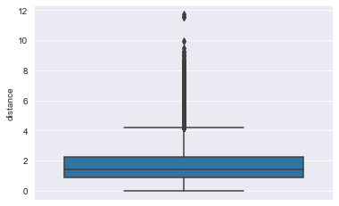

```python
# Visual check
sb.boxplot(data=df, y='distance');
```

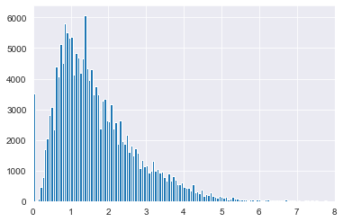

```python
# Let's look at the distribution of traveled distance now; we'll limit it to 8 km because the box plot shows that the majority of values are less than this number.
plt.hist(data=df, x='distance', bins=200);
plt.xlim((0,8));
```

## Question 2:

> **How about the last numerical value : duration ?**

```python
# Duration in seconds to duration in minutes
df['duration_min'] = df['duration_sec']/60
df['duration_min'] = df['duration_min'].astype(int)
```

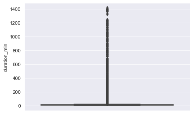

```python
# # Determine the maximum duration value.
sb.boxplot(data=df, y='duration_min');
```

```python
(df['duration_min'].max())/60
```

```
23.483333333333334
```

### Observation 2.1:

> **This maximum value is unrealistic. Someone may have kept the bike for 23 hours, but they did not ride for 23 hours constantly. Let's just preserve the trips that took less than two hours.**

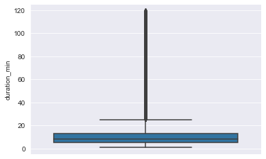

```python
df = df[df['duration_min'] < 120]
sb.boxplot(data=df, y='duration_min');
```

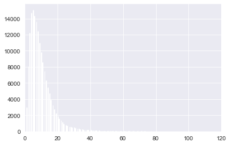

```python
plt.hist(data=df, x='duration_min', bins=400)
plt.xlim((0,120));
```

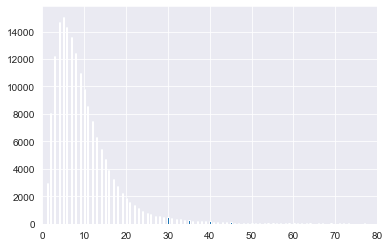

```python
# Let's set the xlimit to 80 for better readability
plt.hist(data=df, x='duration_min', bins=400)
plt.xlim((0,80));
```

### Feature Engineering

To simplify the analysis, let us retrieve the time of day, day of the week, or month of the year from start time.

Define: Add columns for the start month, day of the week, and hour, along with figuring out the trip duration in minutes so I can create visuals based on workable units

```python
# Start time weekday
df_clean['start_time_weekday'] = df_clean['start_time'].apply(lambda x: x.strftime('%A')).astype('category')
```

```python
# Start and end time hour
df_clean['start_time_hour'] = df_clean['start_time'].apply(lambda x: x.strftime('%H')).astype(int)
```

```python
# Brief summary of cleaned DataFrame
df_clean.info()
```

```
<class 'pandas.core.frame.DataFrame'>
Int64Index: 174749 entries, 0 to 183411
Data columns (total 19 columns):
 #   Column                   Non-Null Count   Dtype
---  ------                   --------------   -----
 0   duration_sec             174749 non-null  int64
 1   start_time               174749 non-null  datetime64[ns]
 2   end_time                 174749 non-null  datetime64[ns]
 3   start_station_id         174749 non-null  object
 4   start_station_name       174749 non-null  object
 5   start_station_latitude   174749 non-null  float64
 6   start_station_longitude  174749 non-null  float64
 7   end_station_id           174749 non-null  object
 8   end_station_name         174749 non-null  object
 9   end_station_latitude     174749 non-null  float64
 10  end_station_longitude    174749 non-null  float64
 11  bike_id                  174749 non-null  object
 12  user_type                174749 non-null  category
 13  member_birth_year        174749 non-null  int32
 14  member_gender            174749 non-null  category
 15  bike_share_for_all_trip  174749 non-null  object
 16  User_age                 174749 non-null  float64
 17  start_time_weekday       174749 non-null  category
 18  start_time_hour          174749 non-null  int32
dtypes: category(3), datetime64[ns](2), float64(5), int32(2), int64(1), object(6)
memory usage: 21.8+ MB
```

```python
df_clean.sample(5)
```

|  | duration_sec | start_time | end_time | start_station_id | start_station_name | start_station_latitude | start_station_longitude | end_station_id | end_station_name | end_station_latitude | end_station_longitude | bike_id | user_type | member_birth_year | member_gender | bike_share_for_all_trip | User_age | start_time_weekday | start_time_hour |
| --- | --- | --- | --- | --- | --- | --- | --- | --- | --- | --- | --- | --- | --- | --- | --- | --- | --- | --- | --- |
| 155155 | 616 | 2019-02-06 08:59:27.997 | 2019-02-06 09:09:44.166 | 55.0 | Webster St at Grove St | 37.777053 | -122.429558 | 3.0 | Powell St BART Station (Market St at 4th St) | 37.786375 | -122.404904 | 5398 | Subscriber | 1985 | Female | No | 35.0 | Wednesday | 8 |
| 33809 | 680 | 2019-02-24 10:28:01.067 | 2019-02-24 10:39:21.292 | 29.0 | O'Farrell St at Divisadero St | 37.782405 | -122.439446 | 56.0 | Koshland Park | 37.773414 | -122.427317 | 4452 | Subscriber | 1988 | Female | No | 32.0 | Sunday | 10 |
| 10338 | 773 | 2019-02-27 20:42:19.144 | 2019-02-27 20:55:12.920 | 370.0 | Jones St at Post St | 37.787327 | -122.413278 | 85.0 | Church St at Duboce Ave | 37.770083 | -122.429156 | 5761 | Subscriber | 1993 | Male | No | 27.0 | Wednesday | 20 |
| 53560 | 762 | 2019-02-21 15:21:09.783 | 2019-02-21 15:33:52.392 | 41.0 | Golden Gate Ave at Polk St | 37.781270 | -122.418740 | 118.0 | Eureka Valley Recreation Center | 37.759177 | -122.436943 | 5832 | Customer | 1976 | Male | No | 44.0 | Thursday | 15 |
| 133534 | 340 | 2019-02-08 18:52:26.980 | 2019-02-08 18:58:07.621 | 239.0 | Bancroft Way at Telegraph Ave | 37.868813 | -122.258764 | 244.0 | Shattuck Ave at Hearst Ave | 37.873676 | -122.268487 | 1742 | Subscriber | 1999 | Male | No | 21.0 | Friday | 18 |

# Exploratory Data Analysis

Let's start with some general graphs to get a sense of our data.

## Univariate Exploration

> **Let's look at and analyze the distributions of individual variables.**

```python
# Removing the rainbow colors and setting to the variable no_color
no_color = sb.color_palette()[0]
```

## Hourly usage of the Ford Go Bike System

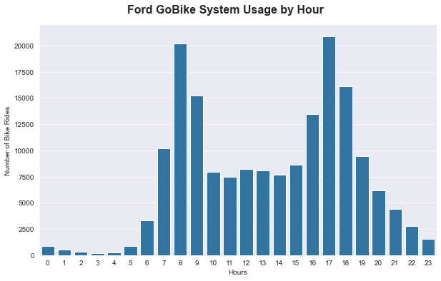

```python
# Hourly usage of the Ford Go Bike System
graph = sb.catplot(data = df_clean, x='start_time_hour', kind='count', color = no_color, aspect = 1.7)

graph.set_axis_labels('Hours', 'Number of Bike Rides')

graph.fig.suptitle('Ford GoBike System Usage by Hour', y=1.05, fontsize=16, fontweight='bold');
```

## Observation 1*

> **Any interesting relationships between the other features (not the main feature(s) of interest)?**

**The bikes were most frequently used between the hours of 8-9 a.m. and 5-6 p.m., which corresponds to a normal workday in the United States. This lends credence to the notion that the bikes are mostly utilized by commuters.**

## Weekday usage of the Ford Go bike system

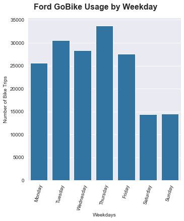

```python
# Weekday usage of the Ford Go bike system
weekday = ['Monday','Tuesday', 'Wednesday', 'Thursday', 'Friday', 'Saturday', 'Sunday']

graph = sb.catplot(data=df_clean, x='start_time_weekday', kind='count', color = no_color, order = weekday)

graph.set_axis_labels('Weekdays', 'Number of Bike Trips')

graph.fig.suptitle('Ford GoBike Usage by Weekday', y=1.05, fontsize=16, fontweight='bold');

graph.set_xticklabels(rotation=75);
```

## Observation 2*

> **Any interesting relationships between the other features (not the main feature(s) of interest)?**

**Tuesdays and Thursday appear to be the most popular days for utilizing the bike sharing system, while Mondays, Wednesdays, and Fridays are quite close. The utilization reduces considerably on Saturdays and Sundays, indicating that the Ford bike sharing system is mostly utilized for commuting during working days.**

## Ford GoBike System Trip Duration in Seconds

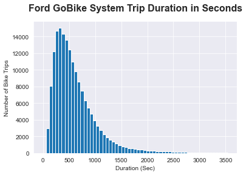

```python
# Duration of the bike rides - in SECONDS
bin_edges = np.arange(0, 3600, 60)

plt.hist(data = df_clean, x = 'duration_sec', bins = bin_edges);

plt.title("Ford GoBike System Trip Duration in Seconds", y=1.05, fontsize=16, fontweight='bold')
plt.xlabel('Duration (Sec)')
plt.ylabel('Number of Bike Trips');
```

```python
df.duration_min.describe(percentiles = [.95])
df.duration_min.describe()
```

```
count    174399.000000
mean         10.171182
std           8.988549
min           1.000000
25%           5.000000
50%           8.000000
75%          13.000000
max         119.000000
Name: duration_min, dtype: float64
```

```python
df.duration_min.mean()
```

```
10.171182174209715
```

## Trip Duration Breakdown

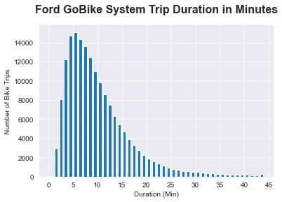

```python
# Duration of the bike rides -in MINUTES
bin_edges = np.arange(0, 45, 1)
ticks = [0, 5, 10, 15, 20, 25, 30,  35, 40, 45]
labels = ['{}'.format(val) for val in ticks]

plt.hist(data = df, x = 'duration_min', bins = bin_edges, rwidth = 0.6);
#sb.distplot(df_cleaned['duration_min'], bins = bin_edges, kde = False, hist_kws = {'alpha' : 1});

plt.title("Ford GoBike System Trip Duration in Minutes", y=1.05, fontsize=16, fontweight='bold')
plt.xlabel('Duration (Min)')
plt.xticks(ticks, labels)
plt.ylabel('Number of Bike Trips');
```